# R base functions for importing data

## 1. Read tabular data into R

#### `read.table()` : 테이블 포맷으로 되어 있는 파일을 읽어 데이터프레임을 반환한다.

- usage: read.table(file, header = FALSE, sep = “”)
- parameter:
  - 파일의 맨 위에 열의 이름을 부여하는 ‘헤더라인’ 을 포함하는 경우, header = TRUE 를 지정하면 데이터프레임을 만들때 열 이름을 붙여준다.
  - 이 함수는 데이터 필드가 빈 칸 (공백이나 탭) 으로 구분될 것이라고 자동으로 가정한다는 특징이 있으므로, 빈칸 대신 다른 구분자를 사용하는 파일이라면 sep 파라미터로 지정한다. (예) sep = “:”
  - 이 함수는 기본으로 문자열 등 비수치형 데이터를 요인(Factor)으로 해석한다. 문자열을 요인으로 해석하지 못하게 하려면 stringAsFactors = FALSE 로 지정하면 된다.
  - *R 에서 true, false 논리연산자는 대문자 TRUE/FALSE 혹은 T/F 로 표시함*

#### `read.csv()`: 값이 comma 로 구분되어 있는 파일(“.csv”)을 읽어 데이터프레임을 반환한다.

- csv : comma-separated value 의 약자
- csv 파일 형식은 엑셀 등 스프레드시트 프로그램, 데이터베이스 관리자 및 대부분의 통계 패키지들이 데이터를 가져오고 내보낼 수 있는 형식이기 때문에 널리 쓰이고 있다.
- usage: read.csv(file, header = TRUE, sep = “,”)
- parameter : read.table 과 동일

### (1) 파일 불러오기

- data 폴더에 저장해놓은 commute.txt 을 읽어와서 commute 라는 변수에 할당함.
- commute.txt 파일 : Departure and arrival times for Dr. Breheny’s evening commute in Summer/Fall 2010 (https://web.as.uky.edu/statistics/users/pbreheny/764-F11/data.html)

```r
# Read tabular data into R as a dataframe
commute <- read.table("data/commute.txt", header = TRUE, sep = "\t", stringsAsFactors = F)
# 첫 6행 읽기
head(commute)
```

```
##         Date Day Depart Arrive
## 1 2010-06-15   T   5:37   6:05
## 2 2010-06-16   W   5:08   5:35
## 3 2010-06-17   H   4:58   5:17
## 4 2010-06-18   F   5:01   5:17
## 5 2010-06-21   M   5:17   5:41
## 6 2010-06-25   F   5:21   5:38
```

commute.txt 데이터를 통해 요일별 출근소요시간을 파악해보자. 이 과정에서 데이터 자료형 변환과 날짜시간 자료형에 대해 함께 살펴보기로 한다.

### (2) 데이터 자료형 변환 및 연산

- 파일에서 읽어들인 데이터프레임의 자료구조를 확인한 후 필요한 형태로 변환한다.
- 자료형을 변환하려면 as.‘자료형’( ) 함수를 사용한다.
  - 예: as.character(), as.factor(), as.numeric(), as.integer()

```r
# commute data frame 구조 확인
str(commute)
```

```
## 'data.frame':    63 obs. of  4 variables:
##  $ Date  : chr  "2010-06-15" "2010-06-16" "2010-06-17" "2010-06-18" ...
##  $ Day   : chr  "T" "W" "H" "F" ...
##  $ Depart: chr  "5:37" "5:08" "4:58" "5:01" ...
##  $ Arrive: chr  "6:05" "5:35" "5:17" "5:17" ...
```

- 변수들은 모두 문자열 자료형(chr)으로 되어 있다.
- 시계열 데이터를 다룰 때 변수를 날짜 타입으로 변환하면 활용에 편리한 점이 많다.
- R의 날짜 자료형으로는 “Date” 객체 이외에 “POSIXct”, “POSIXlt” 등이 있으며, as.POSIXct 함수를 통해 문자 변수를 변환할 수 있다.
- POSIXct 와 POSIXlt 는 모두 POSIXt 를 상속, 구현한 datetime 표기 클래스
  - POSIXct 는 1970-01-01 00:00:00 을 기준으로 이후 시간을 millisecond 단위의 1개 numeric 으로 표기하고 있으며 timezone 을 attribute 로 가지고 있다
  - 반면 POSIXlt 는 연, 월, 일 등 다양한 시간 요소들을 list 형태로 모두 갖고 있다

```r
# Date 와 Depart, Date 와 Arrive 컬럼을 각각 합쳐서 POSIXct 형으로 변환
?POSIXct
as.POSIXct("2018/11/06 4:20")
```

```
## [1] "2018-11-06 04:20:00 KST"
```

```r
as.POSIXlt("2018/11/06 4:20")
```

```
## [1] "2018-11-06 04:20:00 KST"
```

```r
Dep <- as.POSIXct(paste(commute$Date, commute$Depart))  # paste() : 문자열 합치기
Arr <- as.POSIXct(paste(commute$Date, commute$Arrive))

# POSIXct 형으로 변환한 이후에는 기본 연산으로 시간차이를 계산할 수 있음
Arr - Dep
```

```
## Time differences in mins
##  [1] 28 27 19 16 24 17 21 21 17 17 19 21 23 17 18 27 17 20 21 21 22 34 29
## [24] 29 26 22 29 28 16 19 36 27 21 22 22 19 12 21 25 27 23 19 20 29 27 26
## [47] 23 28 19 15 21 21 23 28 21 18 19 32 18 18 25 19 21
```

```r
# 시간차이 계산한 것을 Diff 변수에 할당
Diff <- Arr - Dep
# commute 데이터프레임에 Diff 변수 합치기
new_commute <- cbind(commute, Diff)  # cbind : column 기준으로 합치기
head(new_commute)
```

```
##         Date Day Depart Arrive    Diff
## 1 2010-06-15   T   5:37   6:05 28 mins
## 2 2010-06-16   W   5:08   5:35 27 mins
## 3 2010-06-17   H   4:58   5:17 19 mins
## 4 2010-06-18   F   5:01   5:17 16 mins
## 5 2010-06-21   M   5:17   5:41 24 mins
## 6 2010-06-25   F   5:21   5:38 17 mins
```

### (3) 요일별 출근시간 비교 시각화

“difftime” 자료형으로 생성된 Diff 컬럼을 다시 숫자형으로 변경하여 Boxplot 그래프를 그린다.

```r
# new_commute$Diff 의 데이터타입 확인 : difftime class 는 그래프를 그릴 수 없음
class(new_commute$Diff)
```

```
## [1] "difftime"
```

```r
# Diff 벡터를 숫자형으로 변환하여 new_commute 데이터프레임에 열 추가
Diff <- as.numeric(Diff)
new_commute <- cbind(commute, Diff)
str(new_commute)
```

```
## 'data.frame':    63 obs. of  5 variables:
##  $ Date  : chr  "2010-06-15" "2010-06-16" "2010-06-17" "2010-06-18" ...
##  $ Day   : chr  "T" "W" "H" "F" ...
##  $ Depart: chr  "5:37" "5:08" "4:58" "5:01" ...
##  $ Arrive: chr  "6:05" "5:35" "5:17" "5:17" ...
##  $ Diff  : num  28 27 19 16 24 17 21 21 17 17 ...
```

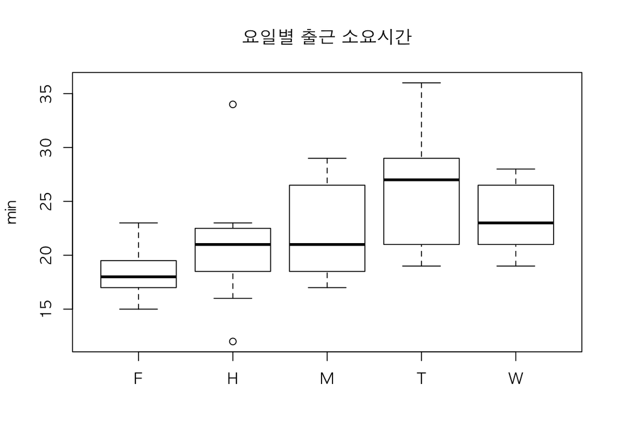

```r
# 상자그림 그리기
boxplot(Diff~Day, new_commute,
        main = "요일별 출근 소요시간",
        ylab = "min")
```

- 기본옵션으로 요일(x축)의 알파벳 순으로 그래프가 그려짐.
- 요일순서로 그래프를 그리려면 요일을 요인(factor)으로 변환하고, 요인의 순서(level)를 지정하면 됨

```r
# Day 컬럼의 자료형을 요인으로 바꾸고 레벨의 순서를 지정
new_commute$Day <- factor(new_commute$Day, levels = c("M", "T", "W", "H", "F"))
str(new_commute)
```

```
## 'data.frame':    63 obs. of  5 variables:
##  $ Date  : chr  "2010-06-15" "2010-06-16" "2010-06-17" "2010-06-18" ...
##  $ Day   : Factor w/ 5 levels "M","T","W","H",..: 2 3 4 5 1 5 1 4 5 1 ...
##  $ Depart: chr  "5:37" "5:08" "4:58" "5:01" ...
##  $ Arrive: chr  "6:05" "5:35" "5:17" "5:17" ...
##  $ Diff  : num  28 27 19 16 24 17 21 21 17 17 ...
```

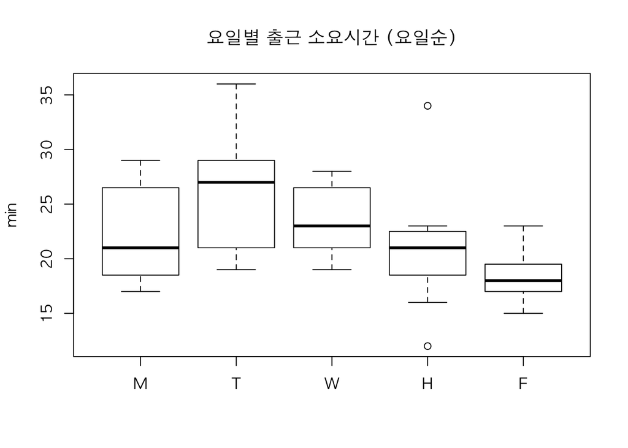

```r
# 상자그림 그리기
boxplot(Diff~Day, new_commute,
        main = "요일별 출근 소요시간 (요일순)",
        ylab = "min")
```

전달력을 높이기 위해 M, T, W, H, F 를 Monday, Tuesday… 로 변경함.

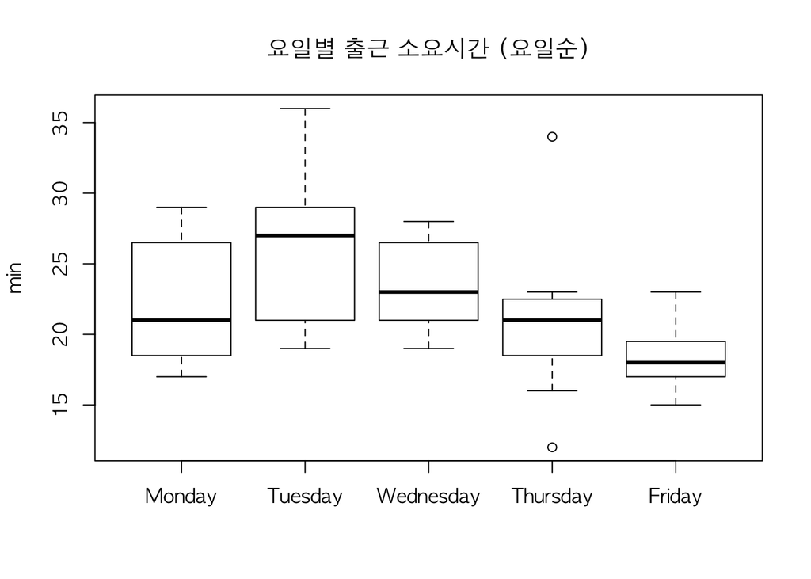

```r
levels(new_commute$Day)[levels(new_commute$Day)=="M"] <- "Monday"
levels(new_commute$Day)[levels(new_commute$Day)=="T"] <- "Tuesday"
levels(new_commute$Day)[levels(new_commute$Day)=="W"] <- "Wednesday"
levels(new_commute$Day)[levels(new_commute$Day)=="H"] <- "Thursday"
levels(new_commute$Day)[levels(new_commute$Day)=="F"] <- "Friday"

boxplot(Diff~Day, new_commute,
        main = "요일별 출근 소요시간 (요일순)",
        ylab = "min")
```

**[Dr.Breheny 의 저녁 출근 소요시간 패턴읽기]**

- 요일별 평균 출근소요시간은 금요일이 가장 짧고 화요일이 가장 길다
- 금요일은 출근소요시간이 거의 일정하고, 월,화요일은 출근소요시간의 차이가 크다.
- 목요일은 출근소요시간의 이상치(outlier) 가 존재한다.

```r
class(new_commute$Date)
```

```
## [1] "character"
```

```r
new_commute$Date <- as.Date(new_commute$Date)
str(new_commute)
```

```
## 'data.frame':    63 obs. of  5 variables:
##  $ Date  : Date, format: "2010-06-15" "2010-06-16" ...
##  $ Day   : Factor w/ 5 levels "Monday","Tuesday",..: 2 3 4 5 1 5 1 4 5 1 ...
##  $ Depart: chr  "5:37" "5:08" "4:58" "5:01" ...
##  $ Arrive: chr  "6:05" "5:35" "5:17" "5:17" ...
##  $ Diff  : num  28 27 19 16 24 17 21 21 17 17 ...
```

```r
library(googleVis)
```

```r
t1 <- gvisMotionChart(new_commute, idvar="Date", timevar="Diff",
                      option=list(width=1000,height=500))
plot(t1)
```

```
## starting httpd help server ...
```

```
##  done
```

### 좀더 살펴보기

#### 날짜와 시간을 다루는 클래스

##### (1) 문자열을 날짜로 변환하기

- as.Date 함수는 출력을 위해 다시 문자열로 변환되는 Date 객체를 반환한다.
- as.Date 가 문자열을 해석할 수 있도록 format 인자를 넣어줘야 한다.
  - 기본으로 yyyy-mm-dd 형식일 것이라고 가정하고 변환해줌.
  - mm/dd/yyyy 또는 mm/dd/yy 로 되어 있다면 format = “%m/%d/%Y” 또는 format = “%m/%d/%y” 를 지정해줘야 함 (대문자 Y는 4자리 연도, 소문자 y는 2자리 연도)

```r
as.Date("2018-09-01")
```

```
## [1] "2018-09-01"
```

```r
as.Date("2018/09/01")
```

```
## [1] "2018-09-01"
```

```r
as.Date("09/01/2018") # "0009-01-20" 으로 변환됨
```

```
## [1] "0009-01-20"
```

```r
as.Date("09/01/2018", format = "%m/%d/%Y")
```

```
## [1] "2018-09-01"
```

```r
as.Date("09/01/18", format = "%m/%d/%y" )
```

```
## [1] "2018-09-01"
```

그 외의 형식으로 되어 있는 문자열을 날짜로 변환하려면?

- yyyy, mm, dd로 표현된 날짜 : ISOdaste 함수를 이용
- ISOdate 함수는 세개의 숫자를 통합해 Date 객체로 변환이 가능한 POSIXct 객체(날짜 및 시간 클래스)로 만듬
- 순수하게 날짜만 가지고 작업할 때는 Date 객체로 변환해서 쓰이지 않는 시간정보의 길이를 줄임

```r
# ISOdate 함수로 POSIXct 객체로 변환
ISOdate(2018, 9, 1)
```

```
## [1] "2018-09-01 12:00:00 GMT"
```

```r
# Date 객체로 변환
as.Date(ISOdate(2018, 9, 1))
```

```
## [1] "2018-09-01"
```

##### (2) 시간자료형에서 하위 원소 추출하기

- Sys.time() 함수를 통해 현재 시스템 시간정보를 받아내면 POSIXct 클래스가 생성된다.
- 문자열을 받아 as.POSIXlt(), as.POSIXct() 함수를 사용해서 시간자료형으로 변환시킨다. POSIXlt 자료형으로 변환시킨 경우 리스트로 저장되어 있어 시, 분, 초, 요일등 하위 원소값으로 뽑아낼 수 있다.

```r
Sys.Date()  # 현재 날짜를 반환하는 함수
```

```
## [1] "2018-11-05"
```

```r
class(Sys.Date())  # Sys.Date() 함수는 Date 객체를 반환
```

```
## [1] "Date"
```

```r
as.POSIXlt(Sys.Date())$wday
```

```
## [1] 1
```

```r
Sys.time()  # 현재 날짜시간을 반환하는 함수
```

```
## [1] "2018-11-05 14:11:05 KST"
```

```r
class(Sys.time())  # Sys.time() 함수는 POSIXct 객체를 반환
```

```
## [1] "POSIXct" "POSIXt"
```

```r
names(unclass(as.POSIXlt(Sys.time())))  # unclass로 리스트의 이름을
```

```
##  [1] "sec"    "min"    "hour"   "mday"   "mon"    "year"   "wday"
##  [8] "yday"   "isdst"  "zone"   "gmtoff"
```

```r
as.POSIXlt(Sys.time())$mon  # 월 (0-11, 0 = 1월)
```

```
## [1] 10
```

```r
as.POSIXlt(Sys.time())$mday  # 해당 달의 몇번째 날 (1-31)
```

```
## [1] 5
```

```r
as.POSIXlt(Sys.time())$wday  # 해당 주의 몇번째 날 (0=6, 0= 일요일)
```

```
## [1] 1
```

```r
as.POSIXlt(Sys.time())$yday  # 해당 해의 몇번째 날 (0-365, 0 = 1월1일)
```

```
## [1] 308
```

```r
when <- as.Date(ISOdate(2018, 9, 1))
as.POSIXlt(when)$mon  # 월 (0-11, 0 = 1월)
```

```
## [1] 8
```

```r
as.POSIXlt(when)$mday  # 해당 달의 몇번째 날 (1-31)
```

```
## [1] 1
```

```r
as.POSIXlt(when)$wday  # 해당 주의 몇번째 날 (0=6, 0= 일요일)
```

```
## [1] 6
```

```r
as.POSIXlt(when)$yday  # 해당 해의 몇번째 날 (0-365, 0 = 1월1일)
```

```
## [1] 243
```

*KST(Korea Standard Time, 한국 표준시) = UTC (Universal Time Coordinated, 세계협정시) +9*

```r
Sys.timezone()
```

```
## [1] "Asia/Seoul"
```

```r
as.POSIXlt(Sys.time(), "GMT")
```

```
## [1] "2018-11-05 05:11:05 GMT"
```

```r
as.POSIXlt(Sys.time(), "EST5EDT")  # the current time in New York
```

```
## [1] "2018-11-05 00:11:05 EST"
```

```r
as.POSIXlt(Sys.time(), "EST" )     # ditto, ignoring DST
```

```
## [1] "2018-11-05 00:11:05 EST"
```

```r
as.POSIXlt(Sys.time(), "HST")      # the current time in Hawaii
```

```
## [1] "2018-11-04 19:11:05 HST"
```

```r
as.POSIXlt(Sys.time(), "Australia/Darwin")
```

```
## [1] "2018-11-05 14:41:05 ACST"
```

RMD 파일에서 R code 추출

```r
# library(knitr)
# purl("1-1a.Timedata.Rmd", encoding = "UTF-8")
```